# Encuesta_Salud_2023

## Análisis univariante de tabaquismo

```r
df_final <- df_final %>%
  mutate(
    Q1_fumar = case_when(
      Q1 == "No contesta" ~ NA_character_,
      TRUE ~ as.character(Q1)
    ),
    Q1_fumar = factor(Q1_fumar,
      levels = c("No fumo ni he fumado nunca de manera habitual",
                 "No fumo actualmente, pero he fumado antes",
                 "Sí fumo, pero no a diario",
                 "Sí, fumo a diario"))
  )
```

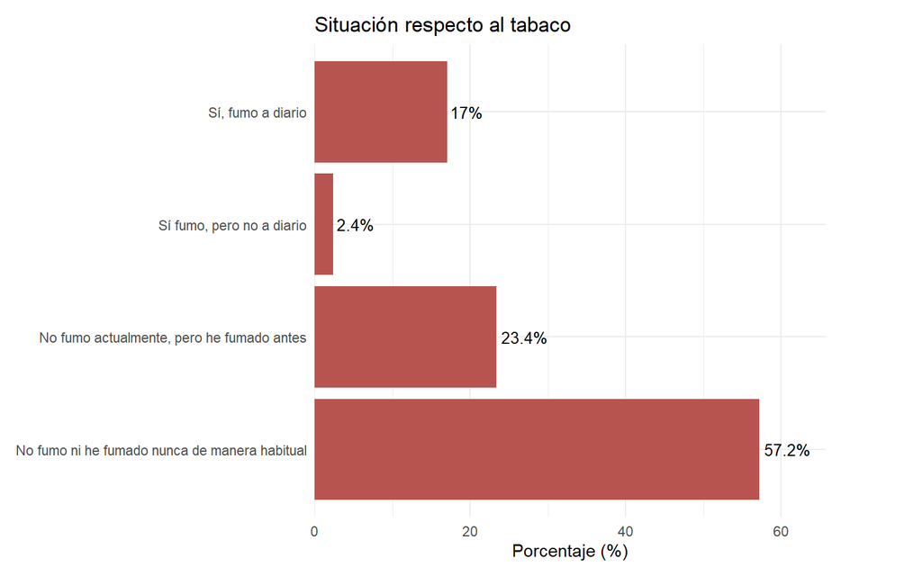

```r
graficar_barras("Q1_fumar", "Situación respecto al tabaco",
                 horizontal = TRUE, color = "#B85450")
```

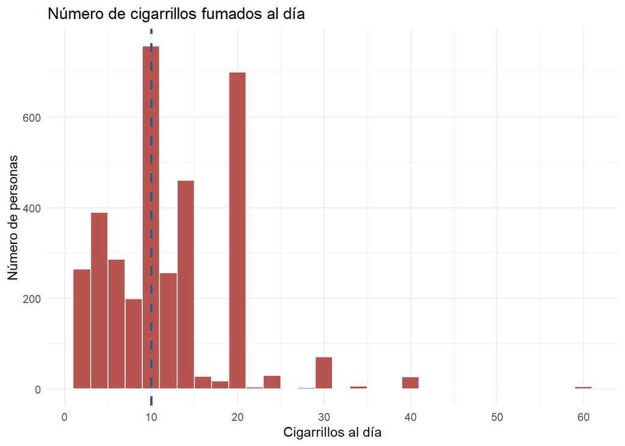

```r
df_final %>%
  filter(Q2 < 100) %>%
  drop_na(Q2) %>%
  ggplot(aes(x = Q2)) +
  geom_histogram(binwidth = 2, fill = "#B85450", color = "white") +
  labs(title = "Número de cigarrillos fumados al día",
       x = "Cigarrillos al día",
       y = "Número de personas") +
  theme_minimal() +
  scale_x_continuous(breaks = seq(0, 60, by = 10)) +
  geom_vline(aes(xintercept = median(Q2, na.rm = TRUE)),
             color = "#2C5F7C", linetype = "dashed", linewidth = 1)
```

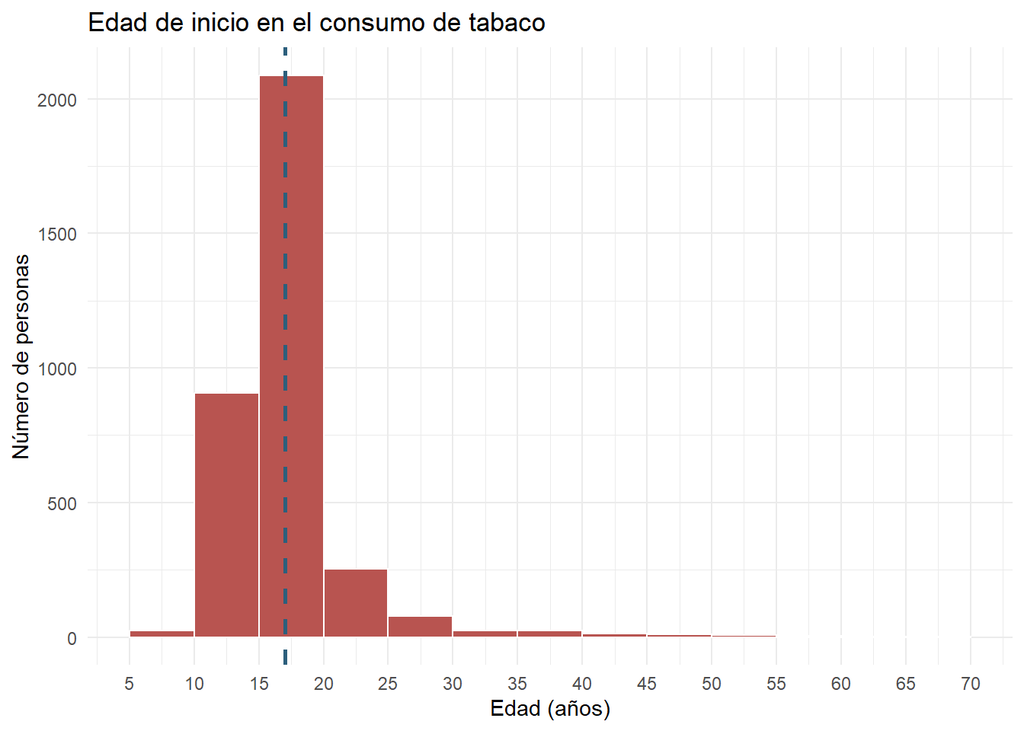

```r
df_final %>%
  drop_na(Q3) %>%
  ggplot(aes(x = Q3)) +
  geom_histogram(binwidth = 5, fill = "#B85450", color = "white", boundary = 0) +
  labs(title = "Edad de inicio en el consumo de tabaco",
       x = "Edad (años)",
       y = "Número de personas") +
  theme_minimal() +
  scale_x_continuous(breaks = seq(0, 80, by = 5)) +
  geom_vline(aes(xintercept = median(Q3, na.rm = TRUE)),
             color = "#2C5F7C", linetype = "dashed", linewidth = 1)
```

La mayoría de los fumadores comenzó a fumar entre los 15 y 20 años, con la mediana situada en esa franja. Muy pocas personas se iniciaron después de los 30, lo que confirma que el hábito se establece mayoritariamente en la adolescencia o inicio de la vida adulta.

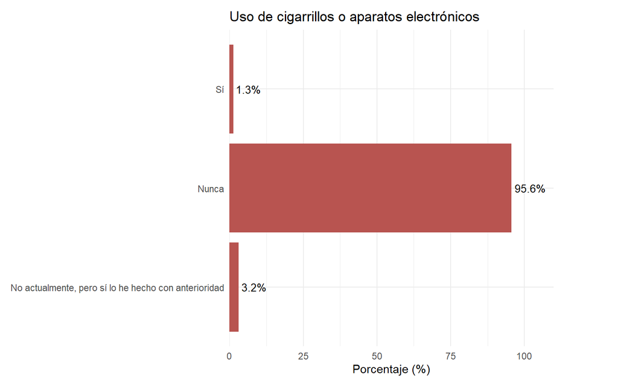

```r
graficar_barras("Q7", "Uso de cigarrillos o aparatos electrónicos",
                 horizontal = TRUE, color = "#B85450", excluir = "No contesta")
```

```r
nrow(df_final)
```

```
## [1] 21032
```

## Análisis bivariante del tabaquismo

```r
tabla <- table(df_final$SEXOa, df_final$Q1_fumar)
chisq.test(tabla)
```

```
##
##  Pearson's Chi-squared test
##
## data:  tabla
## X-squared = 758.05, df = 3, p-value < 2.2e-16
```

```r
tabla_pct <- df_final %>%
  filter(!is.na(SEXOa), !is.na(Q1_fumar)) %>%
  count(SEXOa, Q1_fumar) %>%
  group_by(SEXOa) %>%
  mutate(porcentaje = 100 * n / sum(n))

tabla_pct
```

```
## # A tibble: 8 × 4
## # Groups:   SEXOa [2]
##   SEXOa  Q1_fumar                                          n porcentaje
##   <fct>  <fct>                                         <int>      <dbl>
## 1 Hombre No fumo ni he fumado nunca de manera habitual  4525      47.0
## 2 Hombre No fumo actualmente, pero he fumado antes      2807      29.2
## 3 Hombre Sí fumo, pero no a diario                       268       2.78
## 4 Hombre Sí, fumo a diario                              2024      21.0
## 5 Mujer  No fumo ni he fumado nunca de manera habitual  7442      65.9
## 6 Mujer  No fumo actualmente, pero he fumado antes      2084      18.5
## 7 Mujer  Sí fumo, pero no a diario                       229       2.03
## 8 Mujer  Sí, fumo a diario                              1540      13.6
```

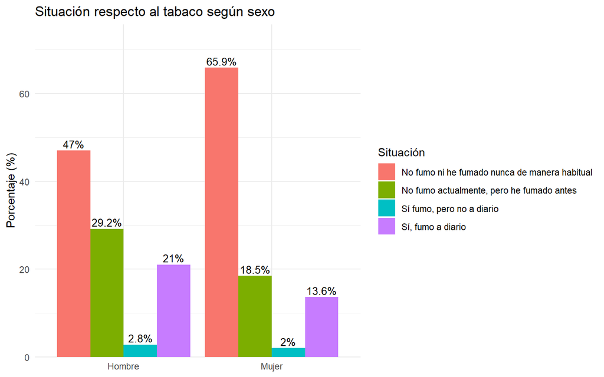

```r
tabla_pct %>%
  ggplot(aes(x = SEXOa, y = porcentaje, fill = Q1_fumar)) +
  geom_col(position = "dodge") +
  geom_text(aes(label = paste0(round(porcentaje, 1), "%")),
            position = position_dodge(width = 0.9), vjust = -0.3, size = 3.5) +
  labs(title = "Situación respecto al tabaco según sexo",
       x = NULL, y = "Porcentaje (%)", fill = "Situación") +
  theme_minimal() +
  scale_y_continuous(expand = expansion(mult = c(0, 0.15)))
```

El test de chi-cuadrado confirma una relación estadísticamente significativa entre sexo y el hábito de fumar (p < 0.001). Al desglosar por sexo se observa que los hombres fuman a diario en mayor proporción que las mujeres (21% frente a 13.6%). Además, las mujeres presentan un porcentaje mayor de personas que nunca han fumado de forma habitual (65.9% frente a 47% en hombres). El porcentaje de exfumadores es algo mayor en hombres que en mujeres (29.2% frente a 18.5%).

```r
tabla_edad <- table(df_final$grupo_edad, df_final$Q1_fumar)
chisq.test(tabla_edad)
```

```
##
##  Pearson's Chi-squared test
##
## data:  tabla_edad
## X-squared = 1911.4, df = 12, p-value < 2.2e-16
```

```r
tabla_edad_pct <- df_final %>%
  filter(!is.na(grupo_edad), !is.na(Q1_fumar)) %>%
  count(grupo_edad, Q1_fumar) %>%
  group_by(grupo_edad) %>%
  mutate(porcentaje = 100 * n / sum(n))

tabla_edad_pct
```

```
## # A tibble: 20 × 4
## # Groups:   grupo_edad [5]
##    grupo_edad Q1_fumar                                          n porcentaje
##    <fct>      <fct>                                         <int>      <dbl>
##  1 15-24      No fumo ni he fumado nunca de manera habitual  1198     80.1
##  2 15-24      No fumo actualmente, pero he fumado antes        67      4.48
##  3 15-24      Sí fumo, pero no a diario                        52      3.48
##  4 15-24      Sí, fumo a diario                               178     11.9
##  5 25-44      No fumo ni he fumado nunca de manera habitual  3021     58.4
##  6 25-44      No fumo actualmente, pero he fumado antes       792     15.3
##  7 25-44      Sí fumo, pero no a diario                       192      3.71
##  8 25-44      Sí, fumo a diario                              1167     22.6
##  9 45-64      No fumo ni he fumado nunca de manera habitual  3451     46.8
## 10 45-64      No fumo actualmente, pero he fumado antes      2046     27.7
## 11 45-64      Sí fumo, pero no a diario                       192      2.60
## 12 45-64      Sí, fumo a diario                              1688     22.9
## 13 65-74      No fumo ni he fumado nunca de manera habitual  1674     50.9
## 14 65-74      No fumo actualmente, pero he fumado antes      1166     35.4
## 15 65-74      Sí fumo, pero no a diario                        41      1.25
## 16 65-74      Sí, fumo a diario                               410     12.5
## 17 75+        No fumo ni he fumado nunca de manera habitual  2623     73.2
## 18 75+        No fumo actualmente, pero he fumado antes       820     22.9
## 19 75+        Sí fumo, pero no a diario                        20      0.558
## 20 75+        Sí, fumo a diario                               121      3.38
```

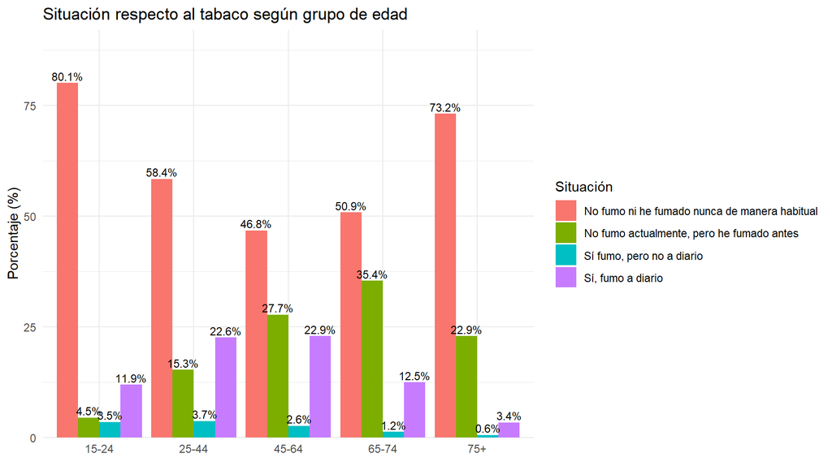

```r
tabla_edad_pct %>%
  ggplot(aes(x = grupo_edad, y = porcentaje, fill = Q1_fumar)) +
  geom_col(position = "dodge") +
  geom_text(aes(label = paste0(round(porcentaje, 1), "%")),
            position = position_dodge(width = 0.9), vjust = -0.3, size = 3) +
  labs(title = "Situación respecto al tabaco según grupo de edad",
       x = NULL, y = "Porcentaje (%)", fill = "Situación") +
  theme_minimal() +
  scale_y_continuous(expand = expansion(mult = c(0, 0.15)))
```

El test de chi-cuadrado confirma una relación estadísticamente muy significativa entre grupo de edad y hábito de fumar (X² = 1911.4, df = 12, p < 0.001). Se observa un patrón claramente generacional: el grupo más joven (15-24 años) es el que menos ha fumado nunca (80.1%), y el consumo diario aumenta en los grupos de 25-44 y 45-64 años (22.6% y 22.9% respectivamente), donde se concentra el mayor porcentaje de fumadores activos. A partir de los 65 años el fumar a diario cae drásticamente (12.5% en 65-74, solo 3.4% en 75+), mientras que el porcentaje de exfumadores aumenta progresivamente con la edad (4.5% en 15-24 hasta 35.4% en 65-74), reflejando el abandono del hábito a lo largo de la vida. Llama la atención que el grupo de 75+ vuelva a mostrar un alto porcentaje de “nunca ha fumado” (73.2%), similar al de los más jóvenes, lo que puede deberse tanto a patrones de consumo distintos en generaciones más mayores como a un efecto de supervivencia (los grandes fumadores tienden a fallecer antes, dejando una muestra de mayores con menor exposición histórica al tabaco).

```r
tabla_estudios <- table(df_final$NIVEST, df_final$Q1_fumar)
chisq.test(tabla_estudios)
```

```
##
##  Pearson's Chi-squared test
##
## data:  tabla_estudios
## X-squared = 605.16, df = 18, p-value < 2.2e-16
```

```r
tabla_estudios_pct <- df_final %>%
  filter(!is.na(NIVEST), NIVEST != "No sabe leer o escribir",
         !is.na(Q1_fumar)) %>%
  count(NIVEST, Q1_fumar) %>%
  group_by(NIVEST) %>%
  mutate(porcentaje = 100 * n / sum(n))

tabla_estudios_pct
```

```
## # A tibble: 24 × 4
## # Groups:   NIVEST [6]
##    NIVEST                                Q1_fumar                   n porcentaje
##    <fct>                                 <fct>                  <int>      <dbl>
##  1 Educación Primaria completa           No fumo ni he fumado …  2348      64.5
##  2 Educación Primaria completa           No fumo actualmente, …   824      22.6
##  3 Educación Primaria completa           Sí fumo, pero no a di…    48       1.32
##  4 Educación Primaria completa           Sí, fumo a diario        420      11.5
##  5 Primera etapa de Enseñanza Secundaria No fumo ni he fumado …  2215      48.9
##  6 Primera etapa de Enseñanza Secundaria No fumo actualmente, …  1015      22.4
##  7 Primera etapa de Enseñanza Secundaria Sí fumo, pero no a di…   115       2.54
##  8 Primera etapa de Enseñanza Secundaria Sí, fumo a diario       1189      26.2
##  9 Estudios de Bachillerato              No fumo ni he fumado …  1565      56.5
## 10 Estudios de Bachillerato              No fumo actualmente, …   663      23.9
## # ℹ 14 more rows
```

```r
df_test <- df_final %>%
  filter(!is.na(NIVEST), NIVEST != "No sabe leer o escribir", !is.na(Q1_fumar)) %>%
  droplevels()

tabla_estudios2 <- table(df_test$NIVEST, df_test$Q1_fumar)
tabla_estudios2
```

```
##
##                                                             No fumo ni he fumado nunca de manera habitual
##   Educación Primaria completa                                                                        2348
##   Primera etapa de Enseñanza Secundaria                                                              2215
##   Estudios de Bachillerato                                                                           1565
##   Enseñanzas profesionales de grado medio o equivalentes                                              913
##   Enseñanzas profesionales de grado superior o equivalentes                                           939
##   Estudios universitarios o equivalentes                                                             2709
##
##                                                             No fumo actualmente, pero he fumado antes
##   Educación Primaria completa                                                                     824
##   Primera etapa de Enseñanza Secundaria                                                          1015
##   Estudios de Bachillerato                                                                        663
##   Enseñanzas profesionales de grado medio o equivalentes                                          430
##   Enseñanzas profesionales de grado superior o equivalentes                                       409
##   Estudios universitarios o equivalentes                                                         1260
##
##                                                             Sí fumo, pero no a diario
##   Educación Primaria completa                                                      48
##   Primera etapa de Enseñanza Secundaria                                           115
##   Estudios de Bachillerato                                                         83
##   Enseñanzas profesionales de grado medio o equivalentes                           58
##   Enseñanzas profesionales de grado superior o equivalentes                        57
##   Estudios universitarios o equivalentes                                          128
##
##                                                             Sí, fumo a diario
##   Educación Primaria completa                                             420
##   Primera etapa de Enseñanza Secundaria                                  1189
##   Estudios de Bachillerato                                                461
##   Enseñanzas profesionales de grado medio o equivalentes                  441
##   Enseñanzas profesionales de grado superior o equivalentes               348
##   Estudios universitarios o equivalentes                                  576
```

```r
chisq.test(tabla_estudios2)
```

```
##
##  Pearson's Chi-squared test
##
## data:  tabla_estudios2
## X-squared = 546.62, df = 15, p-value < 2.2e-16
```

```r
chisq.test(tabla_estudios2)$expected
```

```
##
##                                                             No fumo ni he fumado nunca de manera habitual
##   Educación Primaria completa                                                                   2024.9797
##   Primera etapa de Enseñanza Secundaria                                                         2522.3236
##   Estudios de Bachillerato                                                                      1542.0999
##   Enseñanzas profesionales de grado medio o equivalentes                                        1024.7287
##   Enseñanzas profesionales de grado superior o equivalentes                                      975.2169
##   Estudios universitarios o equivalentes                                                        2599.6511
##
##                                                             No fumo actualmente, pero he fumado antes
##   Educación Primaria completa                                                                871.6373
##   Primera etapa de Enseñanza Secundaria                                                     1085.7153
##   Estudios de Bachillerato                                                                   663.7854
##   Enseñanzas profesionales de grado medio o equivalentes                                     441.0868
##   Enseñanzas profesionales de grado superior o equivalentes                                  419.7748
##   Estudios universitarios o equivalentes                                                    1119.0004
##
##                                                             Sí fumo, pero no a diario
##   Educación Primaria completa                                                92.63870
##   Primera etapa de Enseñanza Secundaria                                     115.39117
##   Estudios de Bachillerato                                                   70.54793
##   Enseñanzas profesionales de grado medio o equivalentes                     46.87925
##   Enseñanzas profesionales de grado superior o equivalentes                  44.61419
##   Estudios universitarios o equivalentes                                    118.92875
##
##                                                             Sí, fumo a diario
##   Educación Primaria completa                                        650.7442
##   Primera etapa de Enseñanza Secundaria                              810.5699
##   Estudios de Bachillerato                                           495.5668
##   Enseñanzas profesionales de grado medio o equivalentes             329.3052
##   Enseñanzas profesionales de grado superior o equivalentes          313.3941
##   Estudios universitarios o equivalentes                             835.4197
```

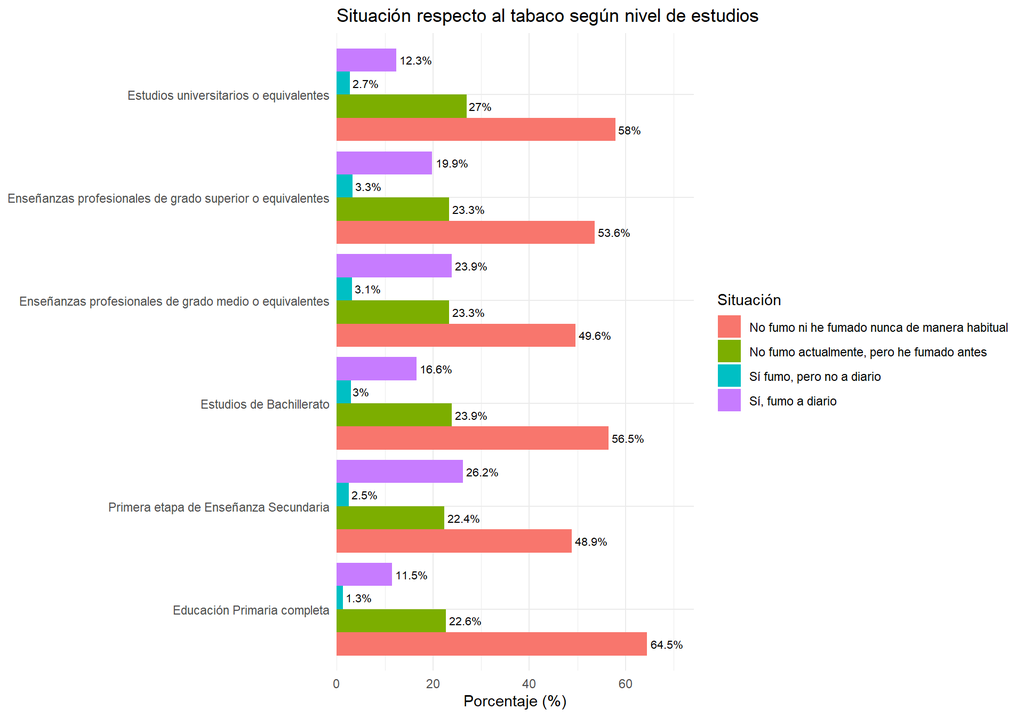

```r
tabla_estudios_pct %>%
  ggplot(aes(x = NIVEST, y = porcentaje, fill = Q1_fumar)) +
  geom_col(position = "dodge") +
  geom_text(aes(label = paste0(round(porcentaje, 1), "%")),
            position = position_dodge(width = 0.9), hjust = -0.1, size = 2.8) +
  labs(title = "Situación respecto al tabaco según nivel de estudios",
       x = NULL, y = "Porcentaje (%)", fill = "Situación") +
  theme_minimal() +
  coord_flip() +
  scale_y_continuous(expand = expansion(mult = c(0, 0.15)))
```

La relación entre nivel de estudios y consumo de tabaco no sigue un patrón estrictamente lineal. El porcentaje de fumadores diarios es más alto en los niveles intermedios de estudios: “Primera etapa de Enseñanza Secundaria” (26.2%) y “Enseñanzas profesionales de grado medio” (23.9%) presentan las tasas de tabaquismo diario más elevadas. En cambio, tanto en el extremo superior (Estudios universitarios, 12.3%) como en el inferior (Educación Primaria completa, 11.5%) el porcentaje de fumadores diarios es menor.

Cabe destacar que en el grupo de Educación Primaria completa la categoría “No fumo ni he fumado nunca” es la más alta de todos los niveles (64.5%), lo cual podría estar influido por la estructura de edad de este grupo (personas de mayor edad,entre las que el hábito tabáquico histórico es distinto), más que por el nivel educativo en sí. Por ello, esta relación debe interpretarse con cautela, ya que puede estar afectada por variables de confusión como la edad.

```r
df_final <- df_final %>%
  mutate(A3_num = as.numeric(as.character(A3)),
         A3_limpio = ifelse(A3_num == 99, NA, A3_num),
         anos_residencia_grupo = case_when(
           A3_limpio <= 5  ~ "0-5",
           A3_limpio <= 10 ~ "6-10",
           A3_limpio <= 20 ~ "11-20",
           A3_limpio <= 30 ~ "21-30",
           A3_limpio > 30  ~ "Más de 30",
           TRUE ~ NA_character_
         ),
         anos_residencia_grupo = factor(anos_residencia_grupo,
           levels = c("0-5", "6-10", "11-20", "21-30", "Más de 30")))

prop.table(table(df_final$anos_residencia_grupo, useNA = "no")) * 100
```

```
##
##       0-5      6-10     11-20     21-30 Más de 30
## 23.036053 18.178368 30.360531 19.051233  9.373814
```

```r
tabla_residencia <- table(df_final$anos_residencia_grupo, df_final$Q1_fumar)
chisq.test(tabla_residencia)
```

```
##
##  Pearson's Chi-squared test
##
## data:  tabla_residencia
## X-squared = 104.08, df = 12, p-value < 2.2e-16
```

```r
tabla_residencia_pct <- df_final %>%
  filter(!is.na(anos_residencia_grupo), !is.na(Q1_fumar)) %>%
  count(anos_residencia_grupo, Q1_fumar) %>%
  group_by(anos_residencia_grupo) %>%
  mutate(porcentaje = 100 * n / sum(n))

tabla_residencia_pct
```

```
## # A tibble: 20 × 4
## # Groups:   anos_residencia_grupo [5]
##    anos_residencia_grupo Q1_fumar                                   n porcentaje
##    <fct>                 <fct>                                  <int>      <dbl>
##  1 0-5                   No fumo ni he fumado nunca de manera …   478      79.3
##  2 0-5                   No fumo actualmente, pero he fumado a…    57       9.45
##  3 0-5                   Sí fumo, pero no a diario                 17       2.82
##  4 0-5                   Sí, fumo a diario                         51       8.46
##  5 6-10                  No fumo ni he fumado nunca de manera …   356      74.3
##  6 6-10                  No fumo actualmente, pero he fumado a…    53      11.1
##  7 6-10                  Sí fumo, pero no a diario                 13       2.71
##  8 6-10                  Sí, fumo a diario                         57      11.9
##  9 11-20                 No fumo ni he fumado nunca de manera …   554      69.7
## 10 11-20                 No fumo actualmente, pero he fumado a…    89      11.2
## 11 11-20                 Sí fumo, pero no a diario                 18       2.26
## 12 11-20                 Sí, fumo a diario                        134      16.9
## 13 21-30                 No fumo ni he fumado nunca de manera …   311      62.2
## 14 21-30                 No fumo actualmente, pero he fumado a…    91      18.2
## 15 21-30                 Sí fumo, pero no a diario                 15       3
## 16 21-30                 Sí, fumo a diario                         83      16.6
## 17 Más de 30             No fumo ni he fumado nunca de manera …   126      51.0
## 18 Más de 30             No fumo actualmente, pero he fumado a…    65      26.3
## 19 Más de 30             Sí fumo, pero no a diario                 10       4.05
## 20 Más de 30             Sí, fumo a diario                         46      18.6
```

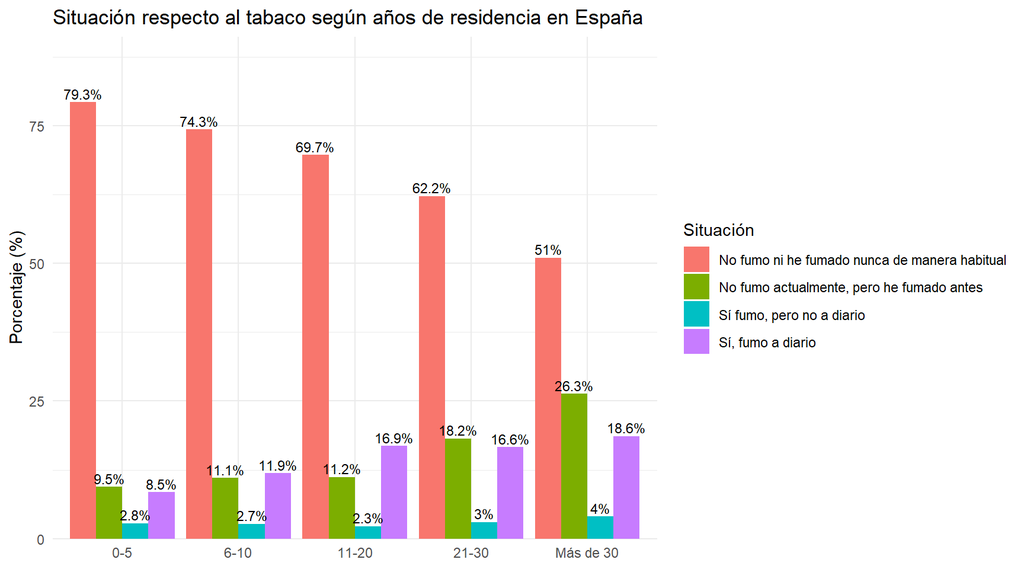

```r
tabla_residencia_pct %>%
  ggplot(aes(x = anos_residencia_grupo, y = porcentaje, fill = Q1_fumar)) +
  geom_col(position = "dodge") +
  geom_text(aes(label = paste0(round(porcentaje, 1), "%")),
            position = position_dodge(width = 0.9), vjust = -0.3, size = 3) +
  labs(title = "Situación respecto al tabaco según años de residencia en España",
       x = NULL, y = "Porcentaje (%)", fill = "Situación") +
  theme_minimal() +
  scale_y_continuous(expand = expansion(mult = c(0, 0.15)))
```

El test de chi-cuadrado confirma una relación estadísticamente significativa entre años de residencia en España y el hábito de fumar (X² = 104.08, df = 12, p < 0.001). Se observa un patrón claro: a medida que aumentan los años de residencia, disminuye el porcentaje de quienes nunca han fumado (del 79.3% con 0-5 años, hasta el 51% con más de 30 años) y aumenta tanto el porcentaje de exfumadores (del 9.5% al 26.3%) como el de fumadores diarios (del 8.5% al 18.6%). Este patrón sugiere un efecto de aculturación: cuanto más tiempo lleva una persona residiendo en España, más se aproxima su comportamiento respecto al tabaco al de la población general del país, posiblemente adoptando hábitos de consumo más similares a los locales con el paso del tiempo.

```r
tabla_c1_fumar <- table(df_final$C1, df_final$Q1_fumar)
chisq.test(tabla_c1_fumar)
```

```
##
##  Pearson's Chi-squared test
##
## data:  tabla_c1_fumar
## X-squared = 250.68, df = 12, p-value < 2.2e-16
```

```r
tabla_c1_fumar_pct <- df_final %>%
  filter(!is.na(C1), !is.na(Q1_fumar)) %>%
  count(C1, Q1_fumar) %>%
  group_by(C1) %>%
  mutate(porcentaje = 100 * n / sum(n))

tabla_c1_fumar_pct
```

```
## # A tibble: 20 × 4
## # Groups:   C1 [5]
##    C1        Q1_fumar                                          n porcentaje
##    <fct>     <fct>                                         <int>      <dbl>
##  1 Bueno     No fumo ni he fumado nunca de manera habitual  5664      55.8
##  2 Bueno     No fumo actualmente, pero he fumado antes      2396      23.6
##  3 Bueno     Sí fumo, pero no a diario                       256       2.52
##  4 Bueno     Sí, fumo a diario                              1834      18.1
##  5 Malo      No fumo ni he fumado nunca de manera habitual   814      55.4
##  6 Malo      No fumo actualmente, pero he fumado antes       404      27.5
##  7 Malo      Sí fumo, pero no a diario                        26       1.77
##  8 Malo      Sí, fumo a diario                               226      15.4
##  9 Muy bueno No fumo ni he fumado nunca de manera habitual  2520      65.0
## 10 Muy bueno No fumo actualmente, pero he fumado antes       598      15.4
## 11 Muy bueno Sí fumo, pero no a diario                       125       3.22
## 12 Muy bueno Sí, fumo a diario                               634      16.4
## 13 Muy malo  No fumo ni he fumado nunca de manera habitual   186      50.8
## 14 Muy malo  No fumo actualmente, pero he fumado antes       106      29.0
## 15 Muy malo  Sí fumo, pero no a diario                         4       1.09
## 16 Muy malo  Sí, fumo a diario                                70      19.1
## 17 Regular   No fumo ni he fumado nunca de manera habitual  2783      55.0
## 18 Regular   No fumo actualmente, pero he fumado antes      1387      27.4
## 19 Regular   Sí fumo, pero no a diario                        86       1.70
## 20 Regular   Sí, fumo a diario                               800      15.8
```

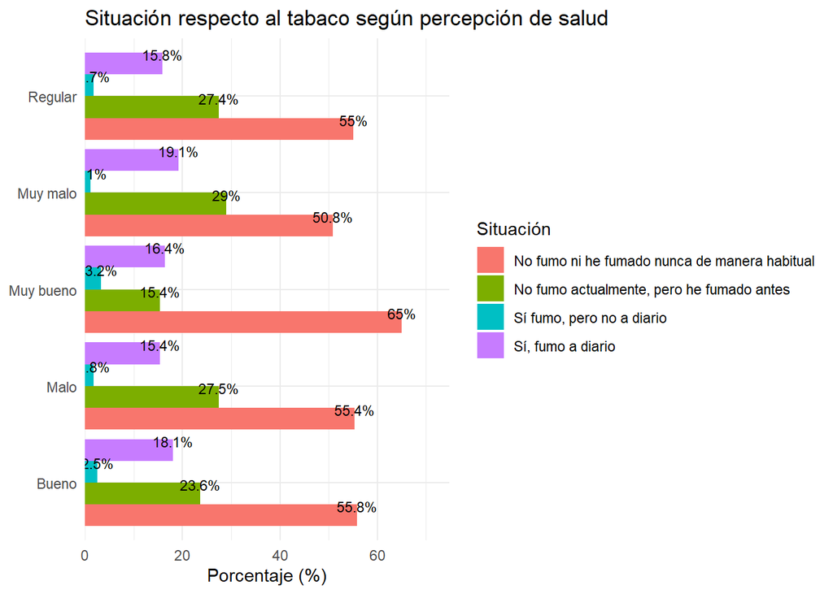

```r
tabla_c1_fumar_pct %>%
  ggplot(aes(x = C1, y = porcentaje, fill = Q1_fumar)) +
  geom_col(position = "dodge") +
  geom_text(aes(label = paste0(round(porcentaje, 1), "%")),
            position = position_dodge(width = 0.9), vjust = -0.3, size = 3) +
  labs(title = "Situación respecto al tabaco según percepción de salud",
       x = NULL, y = "Porcentaje (%)", fill = "Situación") +
  theme_minimal() +
  coord_flip() +
  scale_y_continuous(expand = expansion(mult = c(0, 0.15)))
```

De forma coherente, el grupo “muy bueno” también presenta el mayor porcentaje de personas que nunca han fumado (65%), mientras que en el grupo “muy malo” esa proporción baja al 50.8%, el valor más bajo de la escala. Asimismo, el grupo “muy malo” tiene la tasa más alta de exfumadores (29%), lo que podría reflejar tanto el abandono del hábito tras problemas de salud como el efecto acumulado del tabaquismo en la percepción de bienestar.

Es importante señalar que esta relación es descriptiva y no permite establecer causalidad: no se puede determinar si fumar empeora la percepción de salud, si una salud percibida como peor lleva a fumar más, o si ambas están influidas por otros factores (edad, nivel socioeconómico, enfermedades crónicas, etc.).

```r
tabla_c2_fumar <- table(df_final$C2, df_final$Q1_fumar)
chisq.test(tabla_c2_fumar)
```

```
##
##  Pearson's Chi-squared test
##
## data:  tabla_c2_fumar
## X-squared = 340.44, df = 6, p-value < 2.2e-16
```

```r
tabla_c2_fumar_pct <- df_final %>%
 filter(!is.na(C2), C2 != "No contesta", !is.na(Q1_fumar)) %>%
  count(C2, Q1_fumar) %>%
  group_by(C2) %>%
  mutate(porcentaje = 100 * n / sum(n))

tabla_c2_fumar_pct
```

```
## # A tibble: 8 × 4
## # Groups:   C2 [2]
##   C2    Q1_fumar                                          n porcentaje
##   <fct> <fct>                                         <int>      <dbl>
## 1 No    No fumo ni he fumado nunca de manera habitual  4658      62.1
## 2 No    No fumo actualmente, pero he fumado antes      1226      16.3
## 3 No    Sí fumo, pero no a diario                       226       3.01
## 4 No    Sí, fumo a diario                              1393      18.6
## 5 Sí    No fumo ni he fumado nunca de manera habitual  7189      54.5
## 6 Sí    No fumo actualmente, pero he fumado antes      3603      27.3
## 7 Sí    Sí fumo, pero no a diario                       260       1.97
## 8 Sí    Sí, fumo a diario                              2135      16.2
```

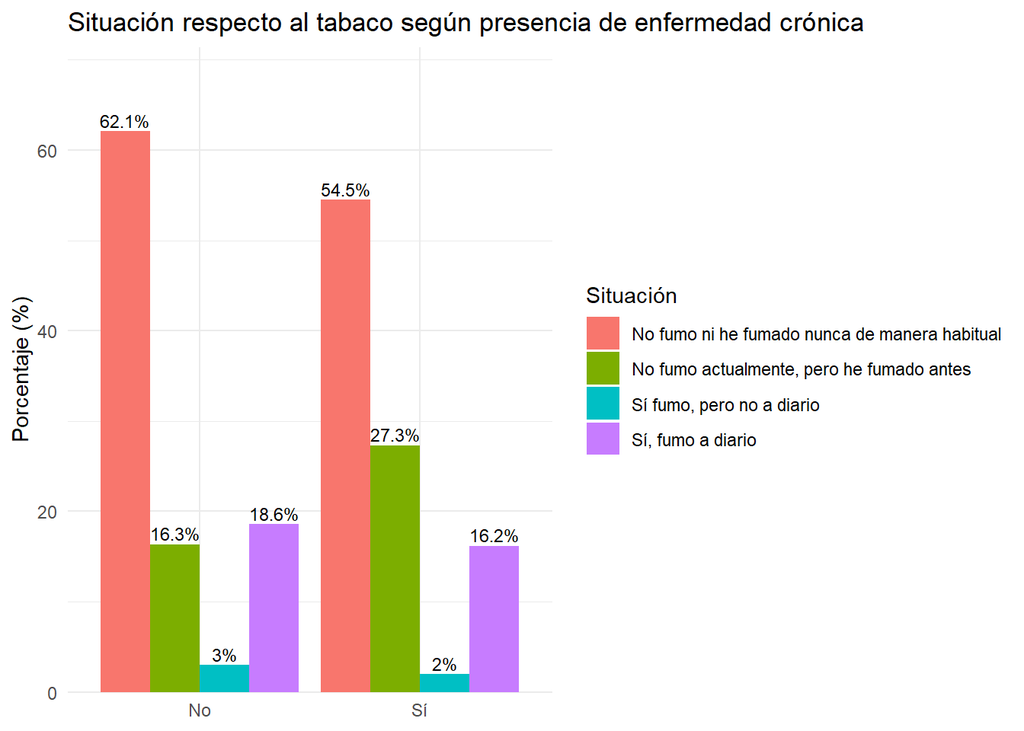

```r
tabla_c2_fumar_pct %>%
  ggplot(aes(x = C2, y = porcentaje, fill = Q1_fumar)) +
  geom_col(position = "dodge") +
  geom_text(aes(label = paste0(round(porcentaje, 1), "%")),
            position = position_dodge(width = 0.9), vjust = -0.3, size = 3) +
  labs(title = "Situación respecto al tabaco según presencia de enfermedad crónica",
       x = NULL, y = "Porcentaje (%)", fill = "Situación") +
  theme_minimal() +
  scale_y_continuous(expand = expansion(mult = c(0, 0.15)))
```

El test de chi-cuadrado confirma una relación estadísticamente significativa entre la presencia de enfermedad o problema de salud crónico y el hábito de fumar (p < 0.001). Las personas sin enfermedad crónica presentan una proporción algo mayor de quienes nunca han fumado (62.1% frente a 54.5%), mientras que entre quienes sí tienen una enfermedad crónica destaca un porcentaje notablemente más alto de exfumadores (27.3% frente a 16.3%). El porcentaje de fumadores diarios es similar en ambos grupos (18.6% sin enfermedad crónica frente a 16.2% con ella). Este patrón sugiere de nuevo un posible efecto de causalidad inversa: es probable que buena parte de las personas con una enfermedad crónica hayan abandonado el tabaco a raíz de su diagnóstico, más que el consumo de tabaco siendo necesariamente el origen directo de la condición declarada.

## Análisis multivariante

Para completar el análisis bivariante, se aplica un Análisis de Correspondencias Múltiples (MCA). Esta técnica permite visualizar en un mismo plano las asociaciones entre el hábito de fumar y el resto de variables sociodemográficas y de salud consideradas, revelando qué categorías tienden a agruparse entre sí.

install.packages(“FactoMineR”) install.packages(“factoextra”)

```r
library(FactoMineR)
library(factoextra)
```

```r
df_mca <- df_final %>%
  select(Q1_fumar, SEXOa, grupo_edad, NIVEST, C1, C2) %>%
  filter(complete.cases(.)) %>%
  droplevels()

mca_res <- MCA(df_mca, graph = FALSE)
```

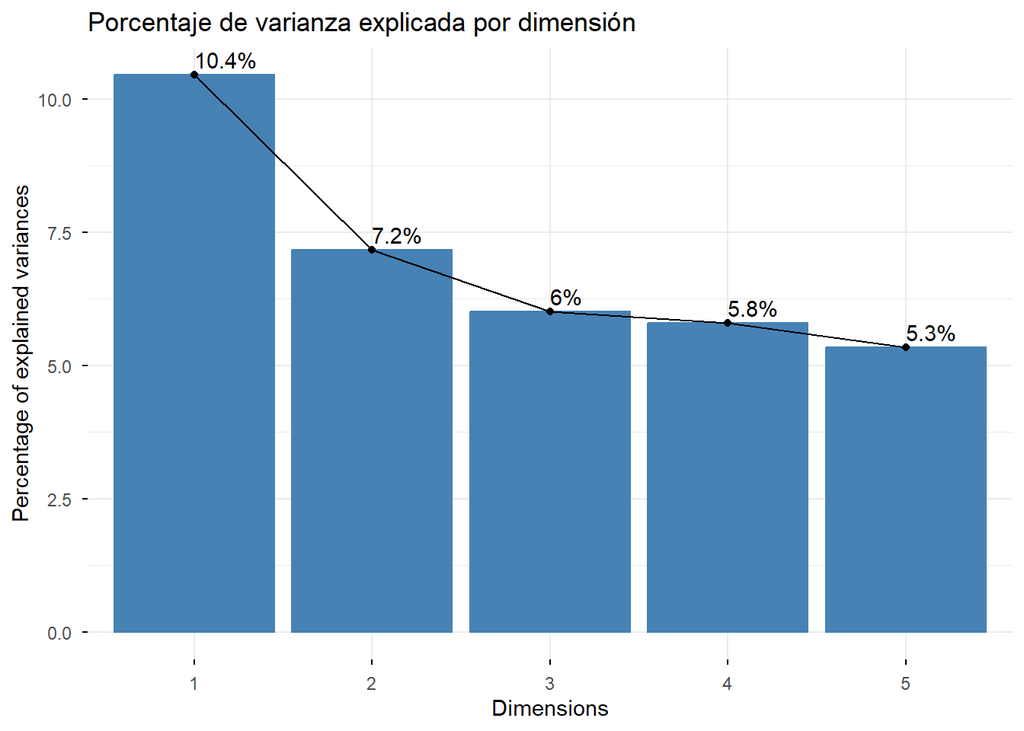

```r
fviz_eig(mca_res, addlabels = TRUE,
         title = "Porcentaje de varianza explicada por dimensión")
```

Las dos primeras dimensiones del Análisis de Correspondencias Múltiples explican un 10,4% y un 7,2% de la inercia total respectivamente (17,6% acumulado). Aunque este porcentaje puede parecer bajo, es un resultado esperable en MCA cuando se trabaja con variables categóricas con múltiples niveles: la información tiende a repartirse entre muchas dimensiones en lugar de concentrarse en las primeras.

De hecho, la caída de varianza entre dimensiones es progresiva (10,4% → 7,2% → 6% → 5,8% → 5,3%), sin un “codo” claro a partir de la segunda dimensión, lo que indica que las dimensiones 3, 4 y 5 aportan cantidades de información similares entre sí.

Por ello, el mapa de categorías en dos dimensiones (Dim 1 y Dim 2) debe interpretarse como una simplificación útil para detectar las asociaciones más relevantes entre tabaco, sexo, edad, nivel de estudios y percepción de salud, sin pretender representar la totalidad de las relaciones existentes en los datos.

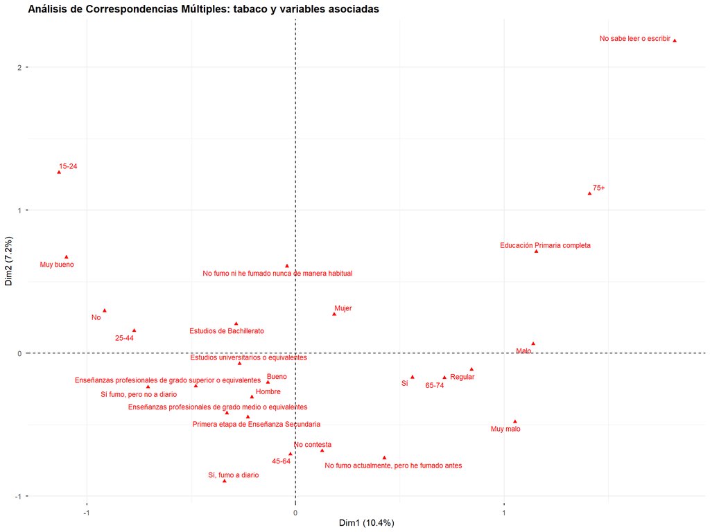

```r
fviz_mca_var(mca_res, repel = TRUE,
             labelsize = 3,
             title = "Análisis de Correspondencias Múltiples: tabaco y variables asociadas") +
  theme(plot.title = element_text(size = 13, face = "bold"))
```

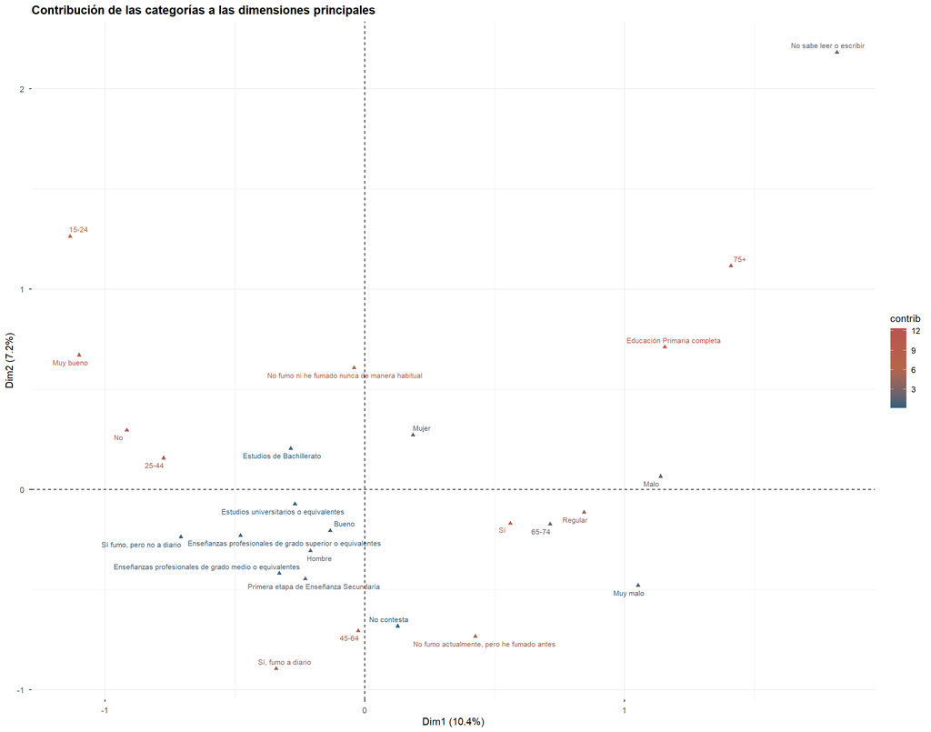

```r
fviz_mca_var(mca_res, col.var = "contrib",
             gradient.cols = c("#2C5F7C", "#B5654A", "#B85450"),
             repel = TRUE,
             labelsize = 2.8,
             title = "Contribución de las categorías a las dimensiones principales") +
  theme(plot.title = element_text(size = 13, face = "bold"))
```